# Supervised Learning - Foundations Project: ReCell

#### FURTHER EDA

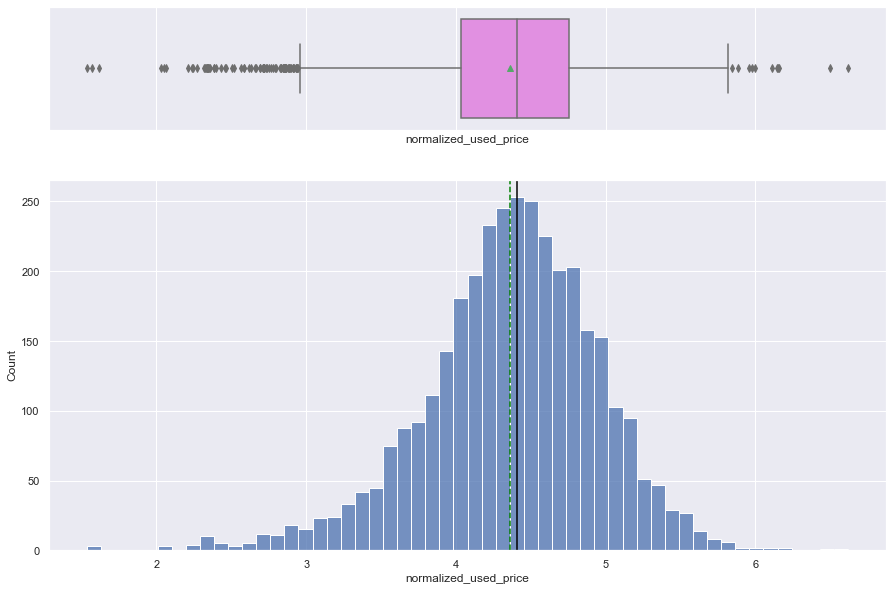

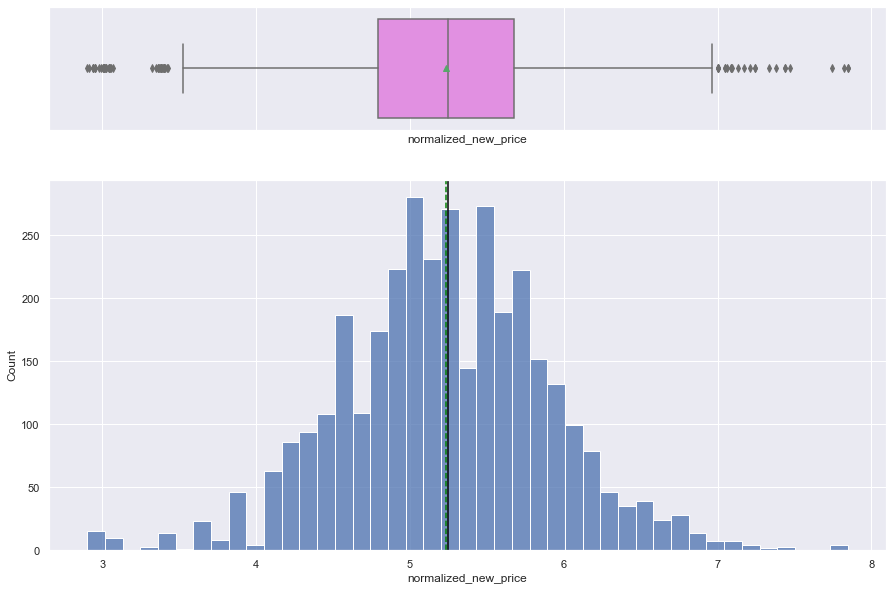

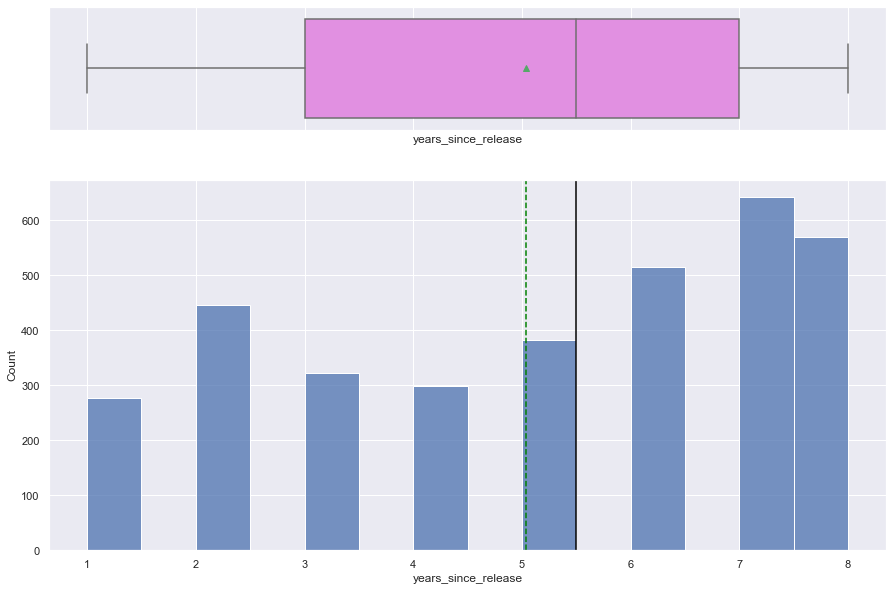

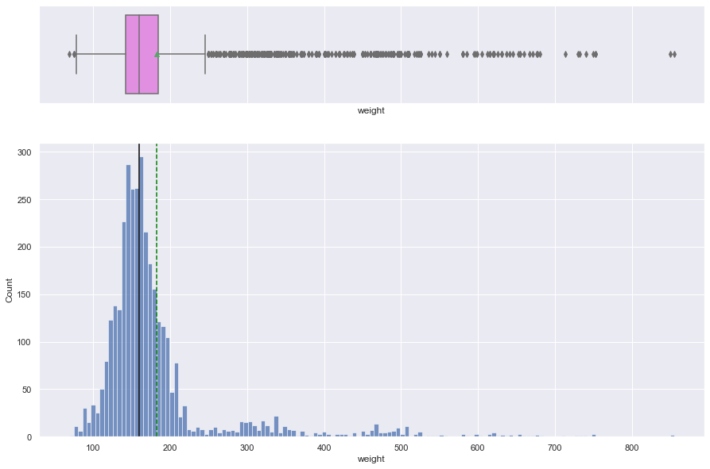

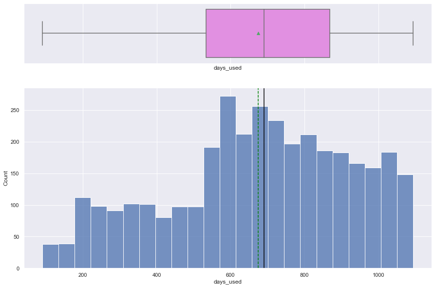

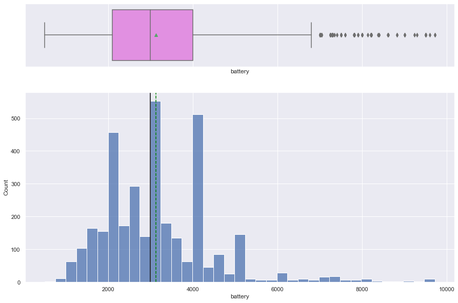

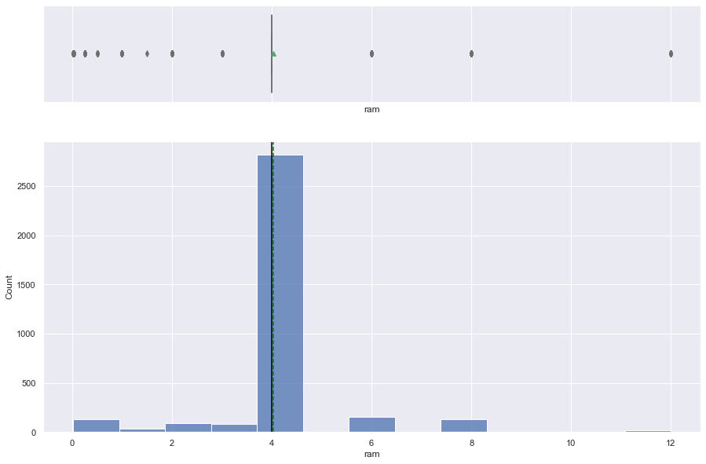

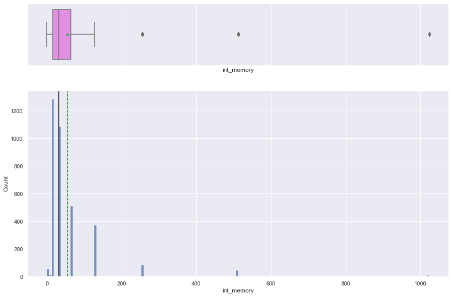

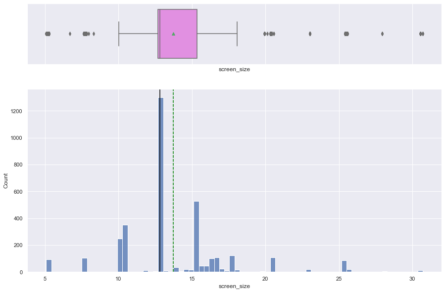

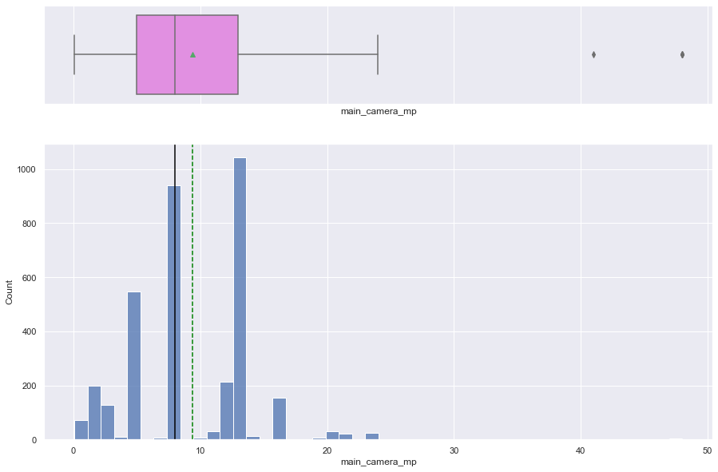

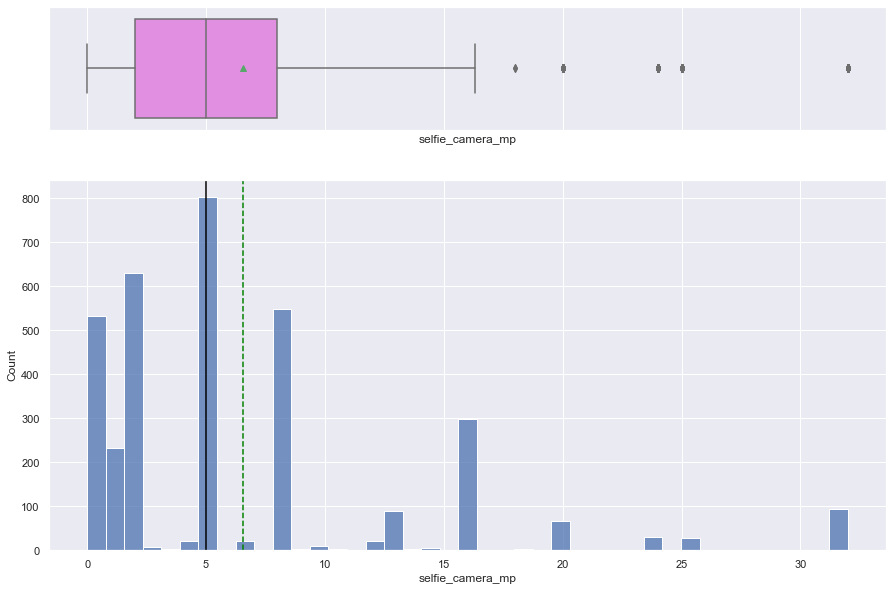

```python
# create boxplot and histogram for numeric columns
for col in [
    "normalized_used_price",
    "normalized_new_price",
    "years_since_release",
    "weight",
    "days_used",
    "battery",
    "ram",
    "int_memory",
    "screen_size",
    "main_camera_mp",
    "selfie_camera_mp",
]:
    histogram_boxplot(df1, col)
```

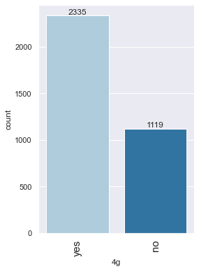

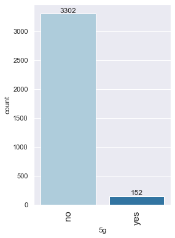

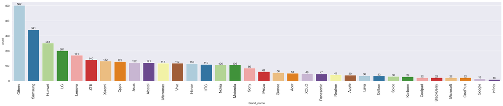

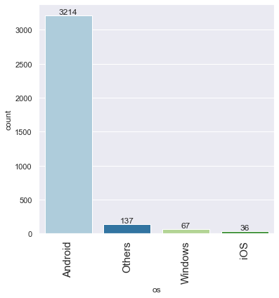

```python
# create bar graphs for categorical columns
for col in ["4g", "5g", "brand_name", "os"]:
    labeled_barplot(df1, col)
```

#### DATA PREPARATION FOR MODELING

```python
# define the dependent and independent variables
X = df1.drop(["normalized_used_price"], axis=1)
y = df1["normalized_used_price"]

print(X.head())  # show first five rows
print()
print(y.head())  # show first five rows
```

```
  brand_name       os  screen_size   4g   5g  main_camera_mp  \
0      Honor  Android        14.50  yes   no            13.0
1      Honor  Android        17.30  yes  yes            13.0
2      Honor  Android        16.69  yes  yes            13.0
3      Honor  Android        25.50  yes  yes            13.0
4      Honor  Android        15.32  yes   no            13.0

   selfie_camera_mp  int_memory  ram  battery  weight  days_used  \
0               5.0        64.0  3.0   3020.0   146.0        127
1              16.0       128.0  8.0   4300.0   213.0        325
2               8.0       128.0  8.0   4200.0   213.0        162
3               8.0        64.0  6.0   7250.0   480.0        345
4               8.0        64.0  3.0   5000.0   185.0        293

   normalized_new_price  years_since_release
0              4.715100                    1
1              5.519018                    1
2              5.884631                    1
3              5.630961                    1
4              4.947837                    1

0    4.307572
1    5.162097
2    5.111084
3    5.135387
4    4.389995
Name: normalized_used_price, dtype: float64
```

```python
# add the intercept to data
X = sm.add_constant(X)
```

```python
# creating dummy variables
X = pd.get_dummies(
    X,
    columns=X.select_dtypes(include=["object", "category"]).columns.tolist(),
    drop_first=True,
)  # create dummies for independent features

X.head()  # show first five rows
```

|  | const | screen_size | main_camera_mp | selfie_camera_mp | int_memory | ram | battery | weight | days_used | normalized_new_price | ... | brand_name_Spice | brand_name_Vivo | brand_name_XOLO | brand_name_Xiaomi | brand_name_ZTE | os_Others | os_Windows | os_iOS | 4g_yes | 5g_yes |
| --- | --- | --- | --- | --- | --- | --- | --- | --- | --- | --- | --- | --- | --- | --- | --- | --- | --- | --- | --- | --- | --- |
| 0 | 1.0 | 14.50 | 13.0 | 5.0 | 64.0 | 3.0 | 3020.0 | 146.0 | 127 | 4.715100 | ... | 0 | 0 | 0 | 0 | 0 | 0 | 0 | 0 | 1 | 0 |
| 1 | 1.0 | 17.30 | 13.0 | 16.0 | 128.0 | 8.0 | 4300.0 | 213.0 | 325 | 5.519018 | ... | 0 | 0 | 0 | 0 | 0 | 0 | 0 | 0 | 1 | 1 |
| 2 | 1.0 | 16.69 | 13.0 | 8.0 | 128.0 | 8.0 | 4200.0 | 213.0 | 162 | 5.884631 | ... | 0 | 0 | 0 | 0 | 0 | 0 | 0 | 0 | 1 | 1 |
| 3 | 1.0 | 25.50 | 13.0 | 8.0 | 64.0 | 6.0 | 7250.0 | 480.0 | 345 | 5.630961 | ... | 0 | 0 | 0 | 0 | 0 | 0 | 0 | 0 | 1 | 1 |
| 4 | 1.0 | 15.32 | 13.0 | 8.0 | 64.0 | 3.0 | 5000.0 | 185.0 | 293 | 4.947837 | ... | 0 | 0 | 0 | 0 | 0 | 0 | 0 | 0 | 1 | 0 |

5 rows × 49 columns

```python
# split the data in 70:30 ratio for train to test data

x_train, x_test, y_train, y_test = train_test_split(
    X, y, test_size=0.3, random_state=1
)  # split the data into train and test in specified ratio
```

```python
print(
    "Number of rows in train data =", x_train.shape[0]
)  # print value in the statement
print("Number of rows in test data =", x_test.shape[0])  # print value in the statement
```

```
Number of rows in train data = 2417
Number of rows in test data = 1037
```

#### Model Building - Linear Regression

```python
olsmodel1 = sm.OLS(y_train, x_train).fit()  # fit OLS model
print(olsmodel1.summary())  # print output
```

```
                              OLS Regression Results
=================================================================================
Dep. Variable:     normalized_used_price   R-squared:                       0.845
Model:                               OLS   Adj. R-squared:                  0.842
Method:                    Least Squares   F-statistic:                     268.7
Date:                   Fri, 06 Jan 2023   Prob (F-statistic):               0.00
Time:                           19:57:12   Log-Likelihood:                 123.94
No. Observations:                   2417   AIC:                            -149.9
Df Residuals:                       2368   BIC:                             133.8
Df Model:                             48
Covariance Type:               nonrobust
=========================================================================================
                            coef    std err          t      P>|t|      [0.025      0.975]
-----------------------------------------------------------------------------------------
const                     1.3285      0.071     18.597      0.000       1.188       1.469
screen_size               0.0244      0.003      7.152      0.000       0.018       0.031
main_camera_mp            0.0203      0.001     13.806      0.000       0.017       0.023
selfie_camera_mp          0.0136      0.001     12.084      0.000       0.011       0.016
int_memory                0.0001   6.97e-05      1.541      0.123   -2.92e-05       0.000
ram                       0.0237      0.005      4.594      0.000       0.014       0.034
battery               -1.588e-05   7.27e-06     -2.185      0.029   -3.01e-05   -1.63e-06
weight                    0.0010      0.000      7.413      0.000       0.001       0.001
days_used              3.506e-05   3.09e-05      1.134      0.257   -2.56e-05    9.57e-05
normalized_new_price      0.4312      0.012     35.144      0.000       0.407       0.455
years_since_release      -0.0248      0.005     -5.444      0.000      -0.034      -0.016
brand_name_Alcatel        0.0152      0.048      0.319      0.750      -0.078       0.109
brand_name_Apple         -0.0123      0.147     -0.083      0.934      -0.301       0.276
brand_name_Asus           0.0196      0.048      0.409      0.683      -0.074       0.114
brand_name_BlackBerry    -0.0298      0.070     -0.424      0.671      -0.167       0.108
brand_name_Celkon        -0.0430      0.066     -0.650      0.516      -0.173       0.087
brand_name_Coolpad        0.0402      0.073      0.552      0.581      -0.103       0.183
brand_name_Gionee         0.0455      0.058      0.787      0.431      -0.068       0.159
brand_name_Google        -0.0312      0.085     -0.369      0.713      -0.197       0.135
brand_name_HTC           -0.0115      0.048     -0.238      0.812      -0.106       0.083
brand_name_Honor          0.0245      0.049      0.497      0.619      -0.072       0.121
brand_name_Huawei        -0.0079      0.044     -0.179      0.858      -0.095       0.079
brand_name_Infinix        0.1547      0.093      1.660      0.097      -0.028       0.337
brand_name_Karbonn        0.0970      0.067      1.446      0.148      -0.035       0.229
brand_name_LG            -0.0151      0.045     -0.334      0.739      -0.104       0.074
brand_name_Lava           0.0337      0.062      0.540      0.589      -0.089       0.156
```

[output cut: 19 more lines]

```
os_Windows               -0.0181      0.045     -0.401      0.688      -0.107       0.070
os_iOS                   -0.0578      0.146     -0.395      0.693      -0.345       0.229
4g_yes                    0.0505      0.016      3.175      0.002       0.019       0.082
5g_yes                   -0.0428      0.032     -1.348      0.178      -0.105       0.019
==============================================================================
Omnibus:                      218.038   Durbin-Watson:                   1.903
Prob(Omnibus):                  0.000   Jarque-Bera (JB):              409.394
Skew:                          -0.609   Prob(JB):                     1.26e-89
Kurtosis:                       4.607   Cond. No.                     1.78e+05
==============================================================================

Notes:
[1] Standard Errors assume that the covariance matrix of the errors is correctly specified.
[2] The condition number is large, 1.78e+05. This might indicate that there are
strong multicollinearity or other numerical problems.
```

#### Interpreting regression results

1. The adjusted r-squared value ranges from 0 to 1 and it reflects the fit of the model . The adjusted r-squared value of this regression is 0.842. This indicates a good regression model.
2. The y-intercept for this model is the const value. This is 1.3285.

#### MODEL PERFORMANCE CHECK

```python
# function to compute adjusted R-squared
def adj_r2_score(predictors, targets, predictions):
    r2 = r2_score(targets, predictions)
    n = predictors.shape[0]
    k = predictors.shape[1]
    return 1 - ((1 - r2) * (n - 1) / (n - k - 1))


# function to compute MAPE
def mape_score(targets, predictions):
    return np.mean(np.abs(targets - predictions) / targets) * 100


# function to compute different metrics to check performance of a regression model
def model_performance_regression(model, predictors, target):
    """
    Function to compute different metrics to check regression model performance

    model: regressor
    predictors: independent variables
    target: dependent variable
    """

    # predicting using the independent variables
    pred = model.predict(predictors)

    r2 = r2_score(target, pred)  # to compute R-squared
    adjr2 = adj_r2_score(predictors, target, pred)  # to compute adjusted R-squared
    rmse = np.sqrt(mean_squared_error(target, pred))  # to compute RMSE
    mae = mean_absolute_error(target, pred)  # to compute MAE
    mape = mape_score(target, pred)  # to compute MAPE

    # creating a dataframe of metrics
    df_perf = pd.DataFrame(
        {
            "RMSE": rmse,
            "MAE": mae,
            "R-squared": r2,
            "Adj. R-squared": adjr2,
            "MAPE": mape,
        },
        index=[0],
    )

    return df_perf
```

```python
# check model performance on train set (seen 70% data)
print("Training Performance\n")
olsmodel1_train_perf = model_performance_regression(olsmodel1, x_train, y_train)
olsmodel1_train_perf
```

```
Training Performance
```

|  | RMSE | MAE | R-squared | Adj. R-squared | MAPE |
| --- | --- | --- | --- | --- | --- |
| 0 | 0.229876 | 0.180362 | 0.844897 | 0.841686 | 4.327657 |

```python
# checking model performance on test set (seen 30% data)
print("Test Performance\n")
olsmodel1_test_perf = model_performance_regression(
    olsmodel1, x_test, y_test
)  # check the performance on test data
olsmodel1_test_perf
```

```
Test Performance
```

|  | RMSE | MAE | R-squared | Adj. R-squared | MAPE |
| --- | --- | --- | --- | --- | --- |
| 0 | 0.23818 | 0.183946 | 0.842714 | 0.834906 | 4.483991 |

- The training $R^2$ is 0.84 so the model is not underfitting.
- The train and test RMSE and MAE are comparable so the model is not overfitting either.
- MAE suggests the model can predict prices of used phones with mean error of 0.18.
- MAPE of 4.5 on the test data means we are able to predict within 4.5% of the used phone prices.

### Checking Linear Regression Assumptions

#### Linear Regression Assumptions

1. **No Multicollinearity**
2. **Linearity of variables**
3. **Independence of error terms**
4. **Normality of error terms**
5. **No Heteroscedasticity**

### TEST FOR MULTICOLLINEARITY

- Test for multicollinearity using VIF.
- **General Rule of thumb**:
  - If VIF is 1 then there is no correlation between the $k$th predictor and the remaining predictor variables.
  - If VIF exceeds 5 or is close to exceeding 5, we say there is moderate multicollinearity.
  - If VIF is 10 or exceeding 10, it shows signs of high multicollinearity.

```python
# define a function to check VIF.


def checking_vif(predictors):
    vif = pd.DataFrame()
    vif["feature"] = predictors.columns

    # calculating VIF for each feature
    vif["VIF"] = [
        variance_inflation_factor(predictors.values, i)
        for i in range(len(predictors.columns))
    ]
    return vif
```

```python
checking_vif(x_train)  # check VIF on train data
```

|  | feature | VIF |
| --- | --- | --- |
| 0 | const | 228.667215 |
| 1 | screen_size | 7.680937 |
| 2 | main_camera_mp | 2.136962 |
| 3 | selfie_camera_mp | 2.810192 |
| 4 | int_memory | 1.361824 |
| 5 | ram | 2.285334 |
| 6 | battery | 4.073649 |
| 7 | weight | 6.380295 |
| 8 | days_used | 2.669623 |
| 9 | normalized_new_price | 3.121700 |
| 10 | years_since_release | 4.885379 |
| 11 | brand_name_Alcatel | 3.405651 |
| 12 | brand_name_Apple | 13.059784 |
| 13 | brand_name_Asus | 3.330536 |
| 14 | brand_name_BlackBerry | 1.632364 |
| 15 | brand_name_Celkon | 1.773996 |
| 16 | brand_name_Coolpad | 1.466551 |
| 17 | brand_name_Gionee | 1.951273 |
| 18 | brand_name_Google | 1.322248 |
| 19 | brand_name_HTC | 3.409874 |
| 20 | brand_name_Honor | 3.345967 |
| 21 | brand_name_Huawei | 5.986360 |
| 22 | brand_name_Infinix | 1.283680 |
| 23 | brand_name_Karbonn | 1.573203 |
| 24 | brand_name_LG | 4.848975 |
| 25 | brand_name_Lava | 1.711336 |
| 26 | brand_name_Lenovo | 4.559192 |
| 27 | brand_name_Meizu | 2.172896 |
| 28 | brand_name_Micromax | 3.363496 |
| 29 | brand_name_Microsoft | 1.869636 |
| 30 | brand_name_Motorola | 3.259888 |
| 31 | brand_name_Nokia | 3.478539 |
| 32 | brand_name_OnePlus | 1.436556 |
| 33 | brand_name_Oppo | 3.971757 |
| 34 | brand_name_Others | 9.710904 |
| 35 | brand_name_Panasonic | 2.105483 |
| 36 | brand_name_Realme | 1.931286 |
| 37 | brand_name_Samsung | 7.539562 |
| 38 | brand_name_Sony | 2.931825 |
| 39 | brand_name_Spice | 1.688731 |
| 40 | brand_name_Vivo | 3.647819 |
| 41 | brand_name_XOLO | 2.136702 |
| 42 | brand_name_Xiaomi | 3.712000 |
| 43 | brand_name_ZTE | 3.796042 |
| 44 | os_Others | 1.861037 |
| 45 | os_Windows | 1.596090 |
| 46 | os_iOS | 11.788811 |
| 47 | 4g_yes | 2.478478 |
| 48 | 5g_yes | 1.847668 |

- There are multiple columns with very high VIF values indicating strong multicollinearity.
- Besides VIF values for dummy variables and constant variable, columns with VIF > 5 will be dropped to reduce multicollinearity.

#### REMOVING MULTICOLLINEARITY

```python
def treating_multicollinearity(predictors, target, high_vif_columns):
    """
    Checking the effect of dropping the columns showing high multicollinearity
    on model performance (adj. R-squared and RMSE)

    predictors: independent variables
    target: dependent variable
    high_vif_columns: columns having high VIF
    """
    # empty lists to store adj. R-squared and RMSE values
    adj_r2 = []
    rmse = []

    # build ols models by dropping one of the high VIF columns at a time
    # store the adjusted R-squared and RMSE in the lists defined previously
    for cols in high_vif_columns:
        # defining the new train set
        train = predictors.loc[:, ~predictors.columns.str.startswith(cols)]

        # create the model
        olsmodel = sm.OLS(target, train).fit()

        # adding adj. R-squared and RMSE to the lists
        adj_r2.append(olsmodel.rsquared_adj)
        rmse.append(np.sqrt(olsmodel.mse_resid))

    # creating a dataframe for the results
    temp = pd.DataFrame(
        {
            "col": high_vif_columns,
            "Adj. R-squared after_dropping col": adj_r2,
            "RMSE after dropping col": rmse,
        }
    ).sort_values(by="Adj. R-squared after_dropping col", ascending=False)
    temp.reset_index(drop=True, inplace=True)

    return temp
```

```python
col_list = ["screen_size", "weight"]  # columns to be treated for multicollinearity
res = treating_multicollinearity(
    x_train, y_train, col_list
)  # check the effect on model performance after dropping specified columns from train data
res
```

|  | col | Adj. R-squared after_dropping col | RMSE after dropping col |
| --- | --- | --- | --- |
| 0 | screen_size | 0.838402 | 0.234688 |
| 1 | weight | 0.838149 | 0.234871 |

```python
col_to_drop = "screen_size"  # specify the column to drop
x_train2 = x_train.loc[
    :, ~x_train.columns.str.startswith(col_to_drop)
]  # specify the train data from which to drop the column specified
x_test2 = x_test.loc[
    :, ~x_test.columns.str.startswith(col_to_drop)
]  # specify the test data from which to drop the column specified

# Check VIF
vif = checking_vif(x_train2)
print("VIF after dropping ", col_to_drop)
vif
```

```
VIF after dropping  screen_size
```

|  | feature | VIF |
| --- | --- | --- |
| 0 | const | 203.629457 |
| 1 | main_camera_mp | 2.134050 |
| 2 | selfie_camera_mp | 2.806637 |
| 3 | int_memory | 1.359659 |
| 4 | ram | 2.285333 |
| 5 | battery | 3.835520 |
| 6 | weight | 2.980031 |
| 7 | days_used | 2.657580 |
| 8 | normalized_new_price | 3.079122 |
| 9 | years_since_release | 4.717913 |
| 10 | brand_name_Alcatel | 3.405487 |
| 11 | brand_name_Apple | 13.002247 |
| 12 | brand_name_Asus | 3.325286 |
| 13 | brand_name_BlackBerry | 1.631042 |
| 14 | brand_name_Celkon | 1.773812 |
| 15 | brand_name_Coolpad | 1.466300 |
| 16 | brand_name_Gionee | 1.941458 |
| 17 | brand_name_Google | 1.319819 |
| 18 | brand_name_HTC | 3.399534 |
| 19 | brand_name_Honor | 3.345643 |
| 20 | brand_name_Huawei | 5.983509 |
| 21 | brand_name_Infinix | 1.283252 |
| 22 | brand_name_Karbonn | 1.572994 |
| 23 | brand_name_LG | 4.831663 |
| 24 | brand_name_Lava | 1.711072 |
| 25 | brand_name_Lenovo | 4.554079 |
| 26 | brand_name_Meizu | 2.169957 |
| 27 | brand_name_Micromax | 3.358651 |
| 28 | brand_name_Microsoft | 1.868144 |
| 29 | brand_name_Motorola | 3.248121 |
| 30 | brand_name_Nokia | 3.463285 |
| 31 | brand_name_OnePlus | 1.436546 |
| 32 | brand_name_Oppo | 3.966161 |
| 33 | brand_name_Others | 9.652604 |
| 34 | brand_name_Panasonic | 2.104655 |
| 35 | brand_name_Realme | 1.928922 |
| 36 | brand_name_Samsung | 7.523133 |
| 37 | brand_name_Sony | 2.926222 |
| 38 | brand_name_Spice | 1.683175 |
| 39 | brand_name_Vivo | 3.647070 |
| 40 | brand_name_XOLO | 2.135756 |
| 41 | brand_name_Xiaomi | 3.706560 |
| 42 | brand_name_ZTE | 3.787533 |
| 43 | os_Others | 1.625493 |
| 44 | os_Windows | 1.596028 |
| 45 | os_iOS | 11.682788 |
| 46 | 4g_yes | 2.477669 |
| 47 | 5g_yes | 1.844409 |

- Multicollinearity has been catered for as seen in the output above.

```python
# rebuild model with updated set of predictors
olsmod1 = sm.OLS(y_train, x_train2).fit()
print(olsmod1.summary())
```

```
                              OLS Regression Results
=================================================================================
Dep. Variable:     normalized_used_price   R-squared:                       0.842
Model:                               OLS   Adj. R-squared:                  0.838
Method:                    Least Squares   F-statistic:                     267.7
Date:                   Fri, 06 Jan 2023   Prob (F-statistic):               0.00
Time:                           19:57:13   Log-Likelihood:                 98.108
No. Observations:                   2417   AIC:                            -100.2
Df Residuals:                       2369   BIC:                             177.7
Df Model:                             47
Covariance Type:               nonrobust
=========================================================================================
                            coef    std err          t      P>|t|      [0.025      0.975]
-----------------------------------------------------------------------------------------
const                     1.4975      0.068     21.984      0.000       1.364       1.631
main_camera_mp            0.0207      0.001     13.933      0.000       0.018       0.024
selfie_camera_mp          0.0139      0.001     12.218      0.000       0.012       0.016
int_memory             8.755e-05   7.04e-05      1.244      0.214   -5.04e-05       0.000
ram                       0.0237      0.005      4.541      0.000       0.013       0.034
battery               -3.314e-06   7.13e-06     -0.465      0.642   -1.73e-05    1.07e-05
weight                    0.0017    9.2e-05     18.294      0.000       0.002       0.002
days_used              2.021e-05   3.12e-05      0.648      0.517   -4.09e-05    8.13e-05
normalized_new_price      0.4414      0.012     35.850      0.000       0.417       0.466
years_since_release      -0.0308      0.005     -6.815      0.000      -0.040      -0.022
brand_name_Alcatel        0.0176      0.048      0.365      0.715      -0.077       0.112
brand_name_Apple          0.0576      0.148      0.388      0.698      -0.233       0.348
brand_name_Asus           0.0060      0.048      0.124      0.901      -0.089       0.101
brand_name_BlackBerry    -0.0441      0.071     -0.621      0.534      -0.183       0.095
brand_name_Celkon        -0.0479      0.067     -0.715      0.475      -0.179       0.083
brand_name_Coolpad        0.0334      0.074      0.453      0.651      -0.111       0.178
brand_name_Gionee         0.0162      0.058      0.278      0.781      -0.098       0.130
brand_name_Google        -0.0571      0.085     -0.669      0.504      -0.225       0.110
brand_name_HTC           -0.0305      0.049     -0.627      0.531      -0.126       0.065
brand_name_Honor          0.0279      0.050      0.562      0.574      -0.070       0.125
brand_name_Huawei        -0.0149      0.045     -0.331      0.740      -0.103       0.073
brand_name_Infinix        0.1425      0.094      1.514      0.130      -0.042       0.327
brand_name_Karbonn        0.1025      0.068      1.512      0.131      -0.030       0.235
brand_name_LG            -0.0345      0.046     -0.754      0.451      -0.124       0.055
brand_name_Lava           0.0281      0.063      0.447      0.655      -0.095       0.152
brand_name_Lenovo         0.0342      0.046      0.748      0.454      -0.055       0.124
```

[output cut: 18 more lines]

```
os_Windows               -0.0161      0.046     -0.353      0.724      -0.106       0.073
os_iOS                   -0.1572      0.147     -1.067      0.286      -0.446       0.132
4g_yes                    0.0484      0.016      3.015      0.003       0.017       0.080
5g_yes                   -0.0524      0.032     -1.632      0.103      -0.115       0.011
==============================================================================
Omnibus:                      228.635   Durbin-Watson:                   1.900
Prob(Omnibus):                  0.000   Jarque-Bera (JB):              426.418
Skew:                          -0.635   Prob(JB):                     2.54e-93
Kurtosis:                       4.619   Cond. No.                     1.78e+05
==============================================================================

Notes:
[1] Standard Errors assume that the covariance matrix of the errors is correctly specified.
[2] The condition number is large, 1.78e+05. This might indicate that there are
strong multicollinearity or other numerical problems.
```

- Although the adjusted r-squared value dropped from 0.842 to 0.838, the difference is insignificant so we can assume the effect of the drop is not much on the model.

#### Interpreting Regression Results

- std error : This shows the level of accuracy of the coefficients. The lower it is, the higher the level of accuracy.
- P>|t|: P-value.
  - For each independent feature, there is a null hypothesis and an alternate hypothesis. In our case, $\beta_i$ is the coefficient of the $i$th independent variable.
    - $H_o$ : Independent feature is not significant ($\beta_i = 0$)
    - $H_a$ : Independent feature is that it is significant ($\beta_i \neq 0$)
  - (P>|t|) gives the p-value for each independent feature to verify the null hypothesis. Considering 0.05 (5%) as significance level, p-value lower than 0.05 is considered to be statistically significant
- Confidence Interval : The range in which the coefficients are likely to fall with a likelihood of 95%

#### High p-value variables

```python
# initial list of columns
predictors = x_train2.copy()  # check for p-values on the right dataset
cols = predictors.columns.tolist()

# set initial max p-value
max_p_value = 1

while len(cols) > 0:
    # define the train set
    x_train_aux = predictors[cols]

    # fit the model
    model = sm.OLS(y_train, x_train_aux).fit()

    # get p-values and the maximum p-value
    p_values = model.pvalues
    max_p_value = max(p_values)

    # name of the variable with maximum p-value
    feature_with_p_max = p_values.idxmax()

    if max_p_value > 0.05:
        cols.remove(feature_with_p_max)
    else:
        break

selected_features = cols
print(selected_features)
```

```
['const', 'main_camera_mp', 'selfie_camera_mp', 'ram', 'weight', 'normalized_new_price', 'years_since_release', 'brand_name_LG', 'brand_name_Micromax', 'brand_name_Others', 'brand_name_Samsung', 'brand_name_Sony', 'brand_name_Xiaomi', 'os_Others', 'os_iOS', '4g_yes']
```

```python
x_train3 = x_train2[
    selected_features
]  # specify the train data from which to select the specified columns
x_test3 = x_test2[
    selected_features
]  # specify the test data from which to select the specified columns
```

```python
olsmodel2 = sm.OLS(
    y_train, x_train3
).fit()  # fitting OLS() on updated dataset (no multicollinearity and no insignificant predictors)
print(olsmodel2.summary())
```

```
                              OLS Regression Results
=================================================================================
Dep. Variable:     normalized_used_price   R-squared:                       0.839
Model:                               OLS   Adj. R-squared:                  0.838
Method:                    Least Squares   F-statistic:                     836.9
Date:                   Fri, 06 Jan 2023   Prob (F-statistic):               0.00
Time:                           19:57:14   Log-Likelihood:                 82.245
No. Observations:                   2417   AIC:                            -132.5
Df Residuals:                       2401   BIC:                            -39.85
Df Model:                             15
Covariance Type:               nonrobust
========================================================================================
                           coef    std err          t      P>|t|      [0.025      0.975]
----------------------------------------------------------------------------------------
const                    1.5550      0.048     32.067      0.000       1.460       1.650
main_camera_mp           0.0205      0.001     14.817      0.000       0.018       0.023
selfie_camera_mp         0.0137      0.001     12.715      0.000       0.012       0.016
ram                      0.0192      0.004      4.284      0.000       0.010       0.028
weight                   0.0017      6e-05     27.652      0.000       0.002       0.002
normalized_new_price     0.4378      0.011     38.982      0.000       0.416       0.460
years_since_release     -0.0303      0.003     -9.174      0.000      -0.037      -0.024
brand_name_LG           -0.0434      0.021     -2.024      0.043      -0.085      -0.001
brand_name_Micromax     -0.0551      0.028     -2.002      0.045      -0.109      -0.001
brand_name_Others       -0.0385      0.014     -2.671      0.008      -0.067      -0.010
brand_name_Samsung      -0.0515      0.017     -3.071      0.002      -0.084      -0.019
brand_name_Sony         -0.0685      0.031     -2.242      0.025      -0.128      -0.009
brand_name_Xiaomi        0.0772      0.026      2.994      0.003       0.027       0.128
os_Others               -0.1410      0.027     -5.223      0.000      -0.194      -0.088
os_iOS                  -0.0997      0.045     -2.204      0.028      -0.188      -0.011
4g_yes                   0.0456      0.015      3.002      0.003       0.016       0.075
==============================================================================
Omnibus:                      221.131   Durbin-Watson:                   1.897
Prob(Omnibus):                  0.000   Jarque-Bera (JB):              410.000
Skew:                          -0.620   Prob(JB):                     9.32e-90
Kurtosis:                       4.592   Cond. No.                     2.27e+03
==============================================================================

Notes:
[1] Standard Errors assume that the covariance matrix of the errors is correctly specified.
[2] The condition number is large, 2.27e+03. This might indicate that there are
strong multicollinearity or other numerical problems.
```

```python
# check model performance on train set (seen 70% data)
print("Training Performance\n")
olsmodel2_train_perf = model_performance_regression(
    olsmodel2, x_train3, y_train
)  # check performance on train data
olsmodel2_train_perf
```

```
Training Performance
```

|  | RMSE | MAE | R-squared | Adj. R-squared | MAPE |
| --- | --- | --- | --- | --- | --- |
| 0 | 0.233876 | 0.182827 | 0.839452 | 0.838382 | 4.392786 |

```python
# check model performance on test set (seen 30% data)
print("Test Performance\n")
olsmodel2_test_perf = model_performance_regression(
    olsmodel2, x_test3, y_test
)  # check performance on test data
olsmodel2_test_perf
```

```
Test Performance
```

|  | RMSE | MAE | R-squared | Adj. R-squared | MAPE |
| --- | --- | --- | --- | --- | --- |
| 0 | 0.241127 | 0.185871 | 0.838798 | 0.836269 | 4.537939 |

```python
print(olsmodel2.summary())  # print regression results to verify high p-values
```

```
                              OLS Regression Results
=================================================================================
Dep. Variable:     normalized_used_price   R-squared:                       0.839
Model:                               OLS   Adj. R-squared:                  0.838
Method:                    Least Squares   F-statistic:                     836.9
Date:                   Fri, 06 Jan 2023   Prob (F-statistic):               0.00
Time:                           19:57:14   Log-Likelihood:                 82.245
No. Observations:                   2417   AIC:                            -132.5
Df Residuals:                       2401   BIC:                            -39.85
Df Model:                             15
Covariance Type:               nonrobust
========================================================================================
                           coef    std err          t      P>|t|      [0.025      0.975]
----------------------------------------------------------------------------------------
const                    1.5550      0.048     32.067      0.000       1.460       1.650
main_camera_mp           0.0205      0.001     14.817      0.000       0.018       0.023
selfie_camera_mp         0.0137      0.001     12.715      0.000       0.012       0.016
ram                      0.0192      0.004      4.284      0.000       0.010       0.028
weight                   0.0017      6e-05     27.652      0.000       0.002       0.002
normalized_new_price     0.4378      0.011     38.982      0.000       0.416       0.460
years_since_release     -0.0303      0.003     -9.174      0.000      -0.037      -0.024
brand_name_LG           -0.0434      0.021     -2.024      0.043      -0.085      -0.001
brand_name_Micromax     -0.0551      0.028     -2.002      0.045      -0.109      -0.001
brand_name_Others       -0.0385      0.014     -2.671      0.008      -0.067      -0.010
brand_name_Samsung      -0.0515      0.017     -3.071      0.002      -0.084      -0.019
brand_name_Sony         -0.0685      0.031     -2.242      0.025      -0.128      -0.009
brand_name_Xiaomi        0.0772      0.026      2.994      0.003       0.027       0.128
os_Others               -0.1410      0.027     -5.223      0.000      -0.194      -0.088
os_iOS                  -0.0997      0.045     -2.204      0.028      -0.188      -0.011
4g_yes                   0.0456      0.015      3.002      0.003       0.016       0.075
==============================================================================
Omnibus:                      221.131   Durbin-Watson:                   1.897
Prob(Omnibus):                  0.000   Jarque-Bera (JB):              410.000
Skew:                          -0.620   Prob(JB):                     9.32e-90
Kurtosis:                       4.592   Cond. No.                     2.27e+03
==============================================================================

Notes:
[1] Standard Errors assume that the covariance matrix of the errors is correctly specified.
[2] The condition number is large, 2.27e+03. This might indicate that there are
strong multicollinearity or other numerical problems.
```

#### TEST FOR LINEARITY AND INDEPENDENCE

```python
# create a dataframe with actual, fitted and residual values
df_pred = pd.DataFrame()

df_pred["Actual Values"] = y_train  # actual values
df_pred["Fitted Values"] = olsmodel2.fittedvalues  # predicted values
df_pred["Residuals"] = olsmodel2.resid  # residuals

df_pred.head()  # view first five rows of the dataset
```

|  | Actual Values | Fitted Values | Residuals |
| --- | --- | --- | --- |
| 3026 | 4.087488 | 3.886269 | 0.201219 |
| 1525 | 4.448399 | 4.612933 | -0.164533 |
| 1128 | 4.315353 | 4.302631 | 0.012722 |
| 3003 | 4.282068 | 4.265015 | 0.017053 |
| 2907 | 4.456438 | 4.464538 | -0.008100 |

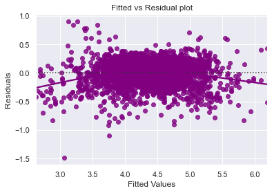

```python
# plot the fitted values vs residuals

sns.residplot(
    data=df_pred, x="Fitted Values", y="Residuals", color="purple", lowess=True
)
plt.xlabel("Fitted Values")  # label of the x-axis
plt.ylabel("Residuals")  # label of the y-axis
plt.title("Fitted vs Residual plot")  # title of the plot
plt.show()  # plot the graph
```

- There is no significant pattern in the plot above so the assumptions of linearity and independence are satisfied.

#### TEST FOR NORMALITY

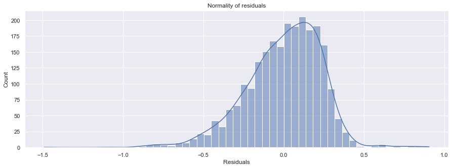

```python
plt.figure(figsize=(15, 5))  # size of the plot
sns.histplot(data=df_pred, x="Residuals", kde=True)  # create histogram with kde curve
# plot the distribution of residuals
plt.title("Normality of residuals")  # title of the plot
plt.show()  # plot and show the graph
```

- The histogram of residuals have a bell shape.

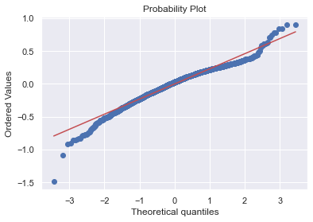

```python
# libraries for the test
import pylab
import scipy.stats as stats

stats.probplot(df_pred["Residuals"], dist="norm", plot=pylab)  # check Q-Q plot
plt.show()  # plot and show the graph
```

- The residuals follow a straight line except for the tails.

```python
# Shapiro-Wilk Test
stats.shapiro(df_pred["Residuals"])
```

```
ShapiroResult(statistic=0.970672607421875, pvalue=7.8236119623297e-22)
```

- The p-value is less than 0.05 hence the residuals are not normal per the Shapiro-Wilk Test. However, we can accept this approximation as being normal and assume the assumption as satisfied.

#### TEST FOR HOMOSCEDASTICITY

```python
# libraries for the test
import statsmodels.stats.api as sms
from statsmodels.compat import lzip

name = ["F statistic", "p-value"]
test = sms.het_goldfeldquandt(
    df_pred["Residuals"], x_train3
)  # applying the Goldfeldquandt test
lzip(name, test)
```

```
[('F statistic', 1.007275375523707), ('p-value', 0.4502040592699097)]
```

- The p-value is greater than 0.05 so we can assume the residuals are homoscedastistic. This assumption is satisfied.

#### PREDICTION ON TEST DATA

```python
# predictions on the test set
pred = olsmodel2.predict(x_test3)

df_pred_test = pd.DataFrame({"Actual": y_test, "Predicted": pred})
df_pred_test.sample(10, random_state=1)
```

|  | Actual | Predicted |
| --- | --- | --- |
| 1995 | 4.566741 | 4.396703 |
| 2341 | 3.696103 | 3.983556 |
| 1913 | 3.592093 | 3.609052 |
| 688 | 4.306495 | 4.078168 |
| 650 | 4.522115 | 5.110516 |
| 2291 | 4.259294 | 4.370388 |
| 40 | 4.997685 | 5.467626 |
| 1884 | 3.875359 | 4.017099 |
| 2538 | 4.206631 | 4.040032 |
| 45 | 5.380450 | 5.301477 |

- The difference between the actual and predicted values are significantly low (means, low error values).
- So we can hence, assume the model returns good prediction results as seen in the output above.

#### FINAL MODEL

```python
# Create copies of the final training and testing sets
x_train_final = x_train3.copy()
x_test_final = x_test3.copy()
```

```python
olsmodel_final = sm.OLS(y_train, x_train_final).fit()  # fit the final model
print(olsmodel_final.summary())
```

```
                              OLS Regression Results
=================================================================================
Dep. Variable:     normalized_used_price   R-squared:                       0.839
Model:                               OLS   Adj. R-squared:                  0.838
Method:                    Least Squares   F-statistic:                     836.9
Date:                   Fri, 06 Jan 2023   Prob (F-statistic):               0.00
Time:                           19:57:16   Log-Likelihood:                 82.245
No. Observations:                   2417   AIC:                            -132.5
Df Residuals:                       2401   BIC:                            -39.85
Df Model:                             15
Covariance Type:               nonrobust
========================================================================================
                           coef    std err          t      P>|t|      [0.025      0.975]
----------------------------------------------------------------------------------------
const                    1.5550      0.048     32.067      0.000       1.460       1.650
main_camera_mp           0.0205      0.001     14.817      0.000       0.018       0.023
selfie_camera_mp         0.0137      0.001     12.715      0.000       0.012       0.016
ram                      0.0192      0.004      4.284      0.000       0.010       0.028
weight                   0.0017      6e-05     27.652      0.000       0.002       0.002
normalized_new_price     0.4378      0.011     38.982      0.000       0.416       0.460
years_since_release     -0.0303      0.003     -9.174      0.000      -0.037      -0.024
brand_name_LG           -0.0434      0.021     -2.024      0.043      -0.085      -0.001
brand_name_Micromax     -0.0551      0.028     -2.002      0.045      -0.109      -0.001
brand_name_Others       -0.0385      0.014     -2.671      0.008      -0.067      -0.010
brand_name_Samsung      -0.0515      0.017     -3.071      0.002      -0.084      -0.019
brand_name_Sony         -0.0685      0.031     -2.242      0.025      -0.128      -0.009
brand_name_Xiaomi        0.0772      0.026      2.994      0.003       0.027       0.128
os_Others               -0.1410      0.027     -5.223      0.000      -0.194      -0.088
os_iOS                  -0.0997      0.045     -2.204      0.028      -0.188      -0.011
4g_yes                   0.0456      0.015      3.002      0.003       0.016       0.075
==============================================================================
Omnibus:                      221.131   Durbin-Watson:                   1.897
Prob(Omnibus):                  0.000   Jarque-Bera (JB):              410.000
Skew:                          -0.620   Prob(JB):                     9.32e-90
Kurtosis:                       4.592   Cond. No.                     2.27e+03
==============================================================================

Notes:
[1] Standard Errors assume that the covariance matrix of the errors is correctly specified.
[2] The condition number is large, 2.27e+03. This might indicate that there are
strong multicollinearity or other numerical problems.
```

```python
# check model performance on train set (seen 70% data)
print("Training Performance\n")
olsmodel_final_train_perf = model_performance_regression(
    olsmodel_final, x_train_final, y_train
)  # check the performance on train data
olsmodel_final_train_perf
```

```
Training Performance
```

|  | RMSE | MAE | R-squared | Adj. R-squared | MAPE |
| --- | --- | --- | --- | --- | --- |
| 0 | 0.233876 | 0.182827 | 0.839452 | 0.838382 | 4.392786 |

```python
# check model performance on test set (seen 30% data)
print("Test Performance\n")
olsmodel_final_test_perf = model_performance_regression(
    olsmodel_final, x_test_final, y_test
)  # check performance on test data
olsmodel_final_test_perf
```

```
Test Performance
```

|  | RMSE | MAE | R-squared | Adj. R-squared | MAPE |
| --- | --- | --- | --- | --- | --- |
| 0 | 0.241127 | 0.185871 | 0.838798 | 0.836269 | 4.537939 |

- The model is able to explain ~84% of the variation in the data
- The train and test RMSE and MAE are low and comparable so the model is not overfitting.
- The MAPE on the test suggests we can predict within ~5% of the used phone prices.
- All this makes our model good for prediction and inference